# Lab 1: Nonlinear Regression

Maarten van der Velde

# 1. Preparation

```r
library(mgcv)
library(itsadug)
library(dplyr)
library(ggplot2)
library(colorspace)
```

## Load data

```r
download.file("http://www.jacolienvanrij.com/Courses/LOT2018/data/LD_RT.rda", "LD_RT.rda")
load("LD_RT.rda")
str(dat)
```

```
'data.frame':   3960 obs. of  14 variables:
 $ Subject         : Factor w/ 20 levels "001_ld","002_ld",..: 1 1 1 1 1 1 1 1 1 1 ...
 $ SubID           : int  1 1 1 1 1 1 1 1 1 1 ...
 $ TRIAL_INDEX     : int  3 4 5 6 7 8 9 10 11 12 ...
 $ Event           : Factor w/ 4000 levels "001_ld.1","002_ld.1",..: 41 61 81 101 121 141 161 181 201 221 ...
 $ Stimulus        : chr  "230-pseudoword" "149-pseudoword" "134-word" "164-pseudoword" ...
 $ Frequency       : num  -1 -1 19.2 -1 -1 ...
 $ Item            : Factor w/ 300 levels "1","10","100",..: 147 56 40 73 92 177 261 133 272 100 ...
 $ KEY_PRESSED     : chr  "x" "x" "n" "x" ...
 $ KEY_RT          : num  567 665 538 658 781 ...
 $ Key_for_Words   : chr  "n" "n" "n" "n" ...
 $ StimulusDuration: num  1500 1500 1500 1500 1500 1500 1500 1500 1500 1500 ...
 $ StimulusType    : chr  "pseudoword" "pseudoword" "word" "pseudoword" ...
 $ WordLength      : int  8 17 6 6 4 5 4 5 3 4 ...
 $ ACC             : num  1 1 1 1 1 1 1 1 1 1 ...
```

### Clean data

```r
d <- dat %>%
  filter(KEY_RT > 0) %>% # Remove missing key presses (RT below 0)
  filter(ACC == 1) %>% # Remove incorrect responses
  droplevels() %>% # Take out empty factor levels
  arrange(SubID, TRIAL_INDEX) # Sort by subject and trial
```

## Question 1: Inspection of data

**How many participants are included in this data set?**

```r
length(unique(d$Subject))
```

```
[1] 20
```

**How many items did they see?**

```r
table(d$Subject)
```

```
001_ld 002_ld 003_ld 004_ld 005_ld 011_ld 012_ld 013_ld 014_ld 019_ld 020_ld 021_ld 023_ld 024_ld 025_ld 026_ld 027_ld 028_ld 029_ld 030_ld
   191    193    190    194    196    195    197    197    197    188    191    193    194    198    191    191    197    195    194    190
```

**What is the range of correct items per participant?**

```r
dat %>%
  group_by(Subject) %>%
  summarise(acc = mean(ACC)) %>%
  pull(acc) %>%
  summary()
```

```
   Min. 1st Qu.  Median    Mean 3rd Qu.    Max.
 0.9545  0.9684  0.9823  0.9803  0.9912  1.0000
```

# 2. Visualisation of the data

```r
rt_by_item <- d %>%
  group_by(StimulusType, Item, WordLength) %>%
  summarise(meanRT = mean(KEY_RT, na.rm = TRUE),
         n_subj = n())
rt_by_length <- rt_by_item %>%
  group_by(StimulusType, WordLength) %>%
  summarise(RT = mean(meanRT, na.rm = TRUE),
            n_item = n())
range(rt_by_length$n_item)
```

```
[1]  1 80
```

Plot of the reaction time averages:

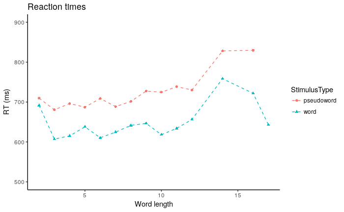

```r
ggplot(rt_by_length, aes(x = WordLength, y = RT, colour = StimulusType)) +
  ylim(500, 900) +
  geom_line(lty = 2) +
  geom_point(aes(pch = StimulusType)) +
  labs(x = "Word length", y = "RT (ms)", title = "Reaction times") +
  theme_classic()
```

Number of items per word-length:

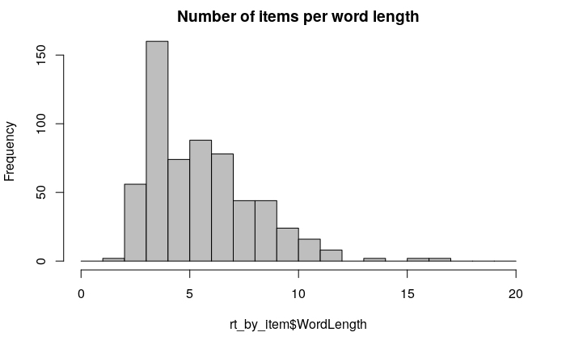

```r
hist(rt_by_item$WordLength, breaks=0:20, col='gray', main = "Number of items per word length")
```

Distribution of RT:

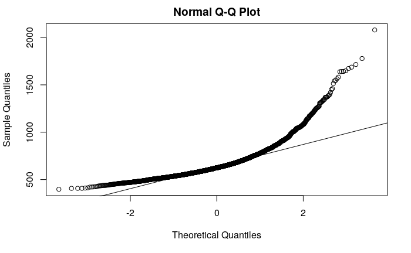

```r
qqnorm(d$KEY_RT)
qqline(d$KEY_RT)
```

## Question 2: Data visualisation

**Do you see an effect of the predictor `StimulusType` (word vs pseudowords) on the average RT?**

Yes, pseudowords have a higher average RT.

**Do you see an effect of `WordLength` on the average RT?**

RT looks fairly constant for words with a length between 2 and 12, but then becomes higher/less regular.

**Do you see an interaction between `StimulusType` and `WordLength`?**

No.

**Describe the range and distribution of the predictor `WordLength`.**

```r
summary(d$WordLength)
```

```
   Min. 1st Qu.  Median    Mean 3rd Qu.    Max.
  2.000   4.000   6.000   6.045   7.000  17.000
```

**Describe what we can infer for the QQ plot of reaction times. What do we need to do before analysis?**

The QQ plot shows that RT is not normally distributed, but heavily skewed to the right (as you would expect with RT). We need to transform it so that it is roughly normal.

# 3. Analysis

## Question 3: Choosing a transformation

Log-transformed RT is still skewed right:

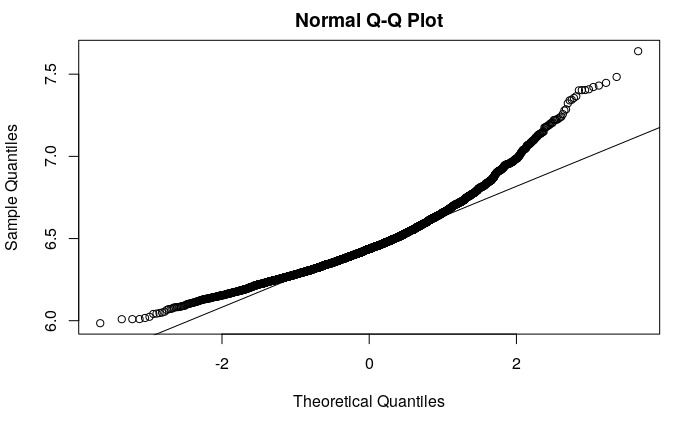

```r
qqnorm(log(d$KEY_RT))
qqline(log(d$KEY_RT))
```

Inverse RT is much closer to a normal distribution, so we’ll use that as the dependent variable in the model:

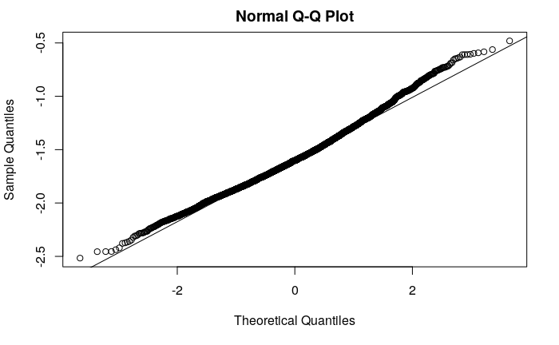

```r
d$invRT <- -1000 / d$KEY_RT
qqnorm(d$invRT)
qqline(d$invRT)
```

## Model 1: effects of word length and stimulus type

**Construct a model that includes the main effects of `StimulusType` and `WordLength`, and their interaction.**

```r
d$StimulusType <- as.factor(d$StimulusType) # gam expects categorical predictors to be coded as factors
m1 <- gam(invRT ~ StimulusType + s(WordLength, by = StimulusType), data = d, method = "ML")
summary(m1)
```

```
Family: gaussian
Link function: identity

Formula:
invRT ~ StimulusType + s(WordLength, by = StimulusType)

Parametric coefficients:
                  Estimate Std. Error t value Pr(>|t|)
(Intercept)      -1.487873   0.006413 -232.00   <2e-16 ***
StimulusTypeword -0.185250   0.009027  -20.52   <2e-16 ***
---
Signif. codes:  0 ‘***’ 0.001 ‘**’ 0.01 ‘*’ 0.05 ‘.’ 0.1 ‘ ’ 1

Approximate significance of smooth terms:
                                       edf Ref.df     F  p-value
s(WordLength):StimulusTypepseudoword 2.129  2.695 12.52  2.3e-07 ***
s(WordLength):StimulusTypeword       1.000  1.000 11.75 0.000615 ***
---
Signif. codes:  0 ‘***’ 0.001 ‘**’ 0.01 ‘*’ 0.05 ‘.’ 0.1 ‘ ’ 1

R-sq.(adj) =  0.108   Deviance explained = 10.9%
-ML = 576.72  Scale est. = 0.078852  n = 3872
```

## Question 4: Interpretation

**What can you conclude from the summary with respect to the difference between words and nonwords?**

The parametric coefficient `StimulusTypeword` shows that inverse RT is lower when the stimulus is a word, meaning that RT is higher for nonwords than for words. This matches the plot we saw earlier.

**What can you conclude from the summary with respect to the *shape* of the two regression lines?**

When`StimulusType` is `word`, the interaction with `WordLength` has only a single effective degree of freedom, which means it can only be a straight line. Since the F-test is significant, this line has a slope that is significantly different from zero.

When `StimulusType` is `pseudoword`, the interaction with `WordLength` is more complex, since it has about 2 edf. We cannot know the exact shape of the regression curve, but we can say that it is significantly different from a straight horizontal line.

Visualise the effects of word length in two different ways:

```r
# using plot:
par(mfrow=c(1,2))
plot(m1, select=1)
abline(h=0)
```

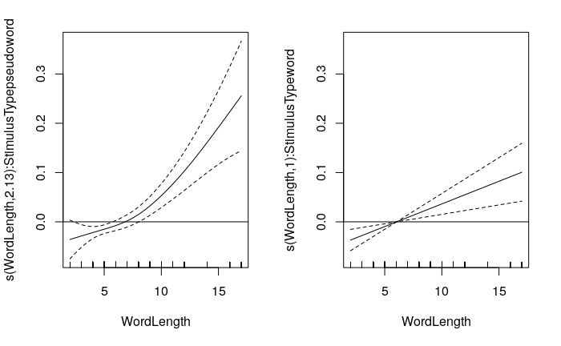

```r
plot(m1, select=2)
abline(h=0)
```

```
Summary:
    * StimulusType : factor; set to the value(s): pseudoword, word.
    * WordLength : numeric predictor; with 30 values ranging from 2.000000 to 17.000000.
```

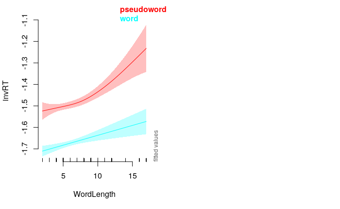

```r
# using plot_smooth:
par(mfrow=c(1,2))
plot_smooth(m1, view="WordLength", plot_all = "StimulusType")
```

## Question 5: Visualisation

**Why are the y-values different for the two types of plots? What is the difference between `plot_smooth` and `plot`?**

The difference is that `plot` only shows the partial effects (i.e., just the smooth terms, not the linear terms), whereas `plot_smooth` includes the linear coefficients (intercept and coefficient for `StimulusType`) so that it shows the actual fitted values.

## Model 2: Testing for significance

**Construct a model that includes only the main effects of `StimulusType` and `WordLength`, not their interaction.**

```r
m2 <- gam(invRT ~ StimulusType + s(WordLength), data = d, method = "ML")
summary(m2)
```

```
Family: gaussian
Link function: identity

Formula:
invRT ~ StimulusType + s(WordLength)

Parametric coefficients:
                  Estimate Std. Error t value Pr(>|t|)
(Intercept)      -1.487766   0.006411 -232.05   <2e-16 ***
StimulusTypeword -0.185119   0.009026  -20.51   <2e-16 ***
---
Signif. codes:  0 ‘***’ 0.001 ‘**’ 0.01 ‘*’ 0.05 ‘.’ 0.1 ‘ ’ 1

Approximate significance of smooth terms:
                edf Ref.df     F  p-value
s(WordLength) 2.322  2.937 15.81 6.22e-10 ***
---
Signif. codes:  0 ‘***’ 0.001 ‘**’ 0.01 ‘*’ 0.05 ‘.’ 0.1 ‘ ’ 1

R-sq.(adj) =  0.109   Deviance explained = 10.9%
-ML = 576.81  Scale est. = 0.078822  n = 3872
```

## Question 6: Visualisation

**Without having plotted the model estimates, what can you conclude about the estimated regression lines of words and pseudowords based on the summary?**

Looking at the parametric coefficients, we can see that once again words have a lower intercept than nonwords (i.e., overall words have a lower RT than non-words). There is also a significant effect of `WordLength` with about 2 effective degrees of freedom (though we don’t know the shape). In this model both stimulus types will have the same regression curve, but with a different intercept.

Compare the two models:

```r
AIC(m1, m2)
```

|  | df | AIC |
| --- | --- | --- |
| m1 | 6.695013 | 1160.936 |
| m2 | 5.937307 | 1158.767 |

```r
compareML(m1, m2)
```

```
m1: invRT ~ StimulusType + s(WordLength, by = StimulusType)

m2: invRT ~ StimulusType + s(WordLength)

Chi-square test of ML scores
-----
  Model    Score Edf Difference    Df p.value Sig.
1    m2 576.8115   4
2    m1 576.7159   6      0.096 2.000   0.909

AIC difference: 2.17, model m2 has lower AIC.
```

```
Only small difference in ML...
```

## Question 7: Model comparison

**Inspect the output. Which model is preferred? What is the conclusion?**

The `AIC` comparison shows that the second model (without interaction) has a lower AIC score, which would make it the preferred model. The `compareML` comparison shows that the second model only has a very slightly higher ML score (what is this?), and that the difference is not significant. Both tests therefore point towards the simpler model as the preferred model. Based on this, we can conclude that the interaction between `WordLength` and `StimulusType` does not contribute to the model.

# 4. Extra: checking residuals

The residuals of the simpler model are normally distributed:

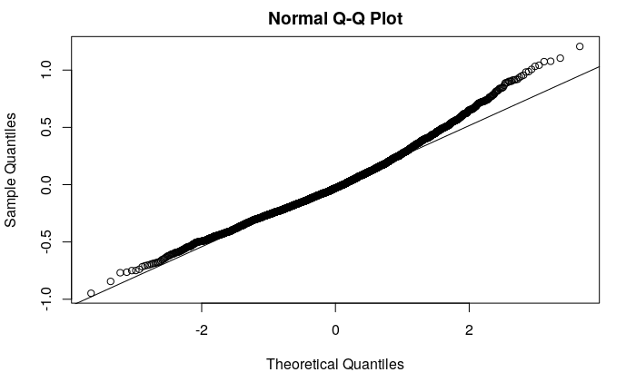

```r
qqnorm(resid(m2))
qqline(resid(m2))
```

Check whether the residuals are autocorrelated:

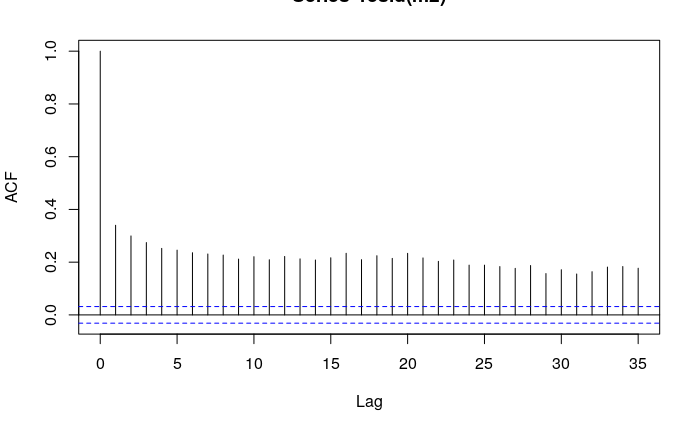

```r
acf(resid(m2))
```

Plot residuals to see if there are trends:

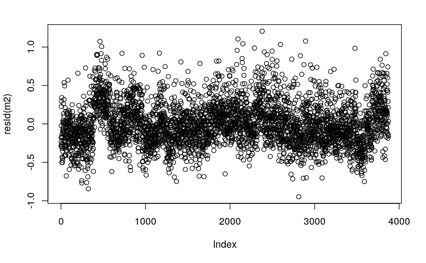

```r
plot(resid(m2))
```

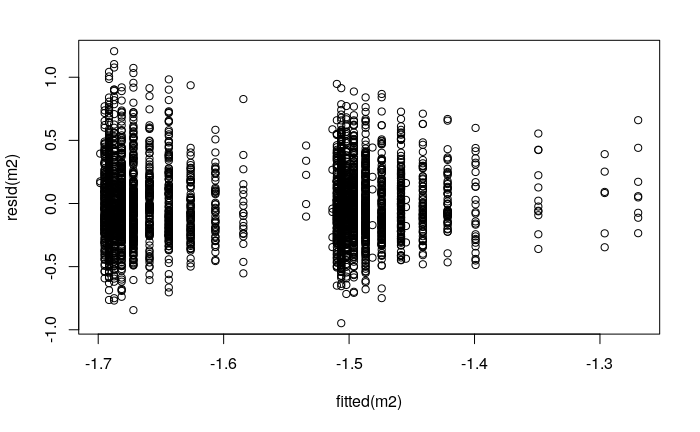

```r
plot(fitted(m2), resid(m2))
```

## Question 8: Residuals

**What do these plots tell you about the residuals? Do you see problems?**

The residuals are roughly normally distributed and are fairly evenly spread around zero for all fitted values. They are however quite consistently autocorrelated (r $\approx$ 0.2), which could be a problem.